# Regression-to-Mean-Adjusted Group Comparison

Goh Gabriel

2024-10-25

## Why it is a bad idea to use the same variable for screening as well as the outcome

We simulate a starting N of 1000, an “inclusion criteria” of being -1 SD or more on a variable, an effect size of the intervention of 0.2 (time1 vs time2), and a test-retest reliability of 0.7

```r
# Load required libraries
library(ggplot2)
library(gridExtra)
library(tidyr)
library(ez)
library(car)
library(lme4)
# Set seed for reproducibility
set.seed(123)

# Parameters
n <- 1000  # Total sample size
sd_cutoff <- -1  # Standard deviation cutoff for screening
effect_size <- 0.2  # Effect size of the intervention
reliability <- 0.7  # Test-retest reliability
```

As the findings below show, a small effect size of ~0.2 turns into an effect size of ~0.8 for the intervention group, and even though the control group was not simulated to have an effect size, it still has an observed effect size of ~0.4.

Levene’s test, as well as the visual plots, suggest significant heterogeneity of variances.

Under these circumstances, the parameters are likely to be highly biased, and should not be trusted.

```r
# Generate initial sample
initial_sample <- rnorm(n, mean = 0, sd = 1)

# Screen participants
screened_sample <- initial_sample[initial_sample <= sd_cutoff]

# Split into control and intervention groups
n_screened <- length(screened_sample)
group <- sample(c("Control", "Intervention"), n_screened, replace = TRUE)

# Create data frame
data <- data.frame(
  id = 1:n_screened,
  group = group,
  time1 = screened_sample
)

# Function to generate time 2 scores
generate_time2 <- function(time1, reliability, effect = 0) {
  true_score <- time1
  error_var <- 1 - reliability
  observed_score <- sqrt(reliability) * true_score +
                    sqrt(error_var) * rnorm(length(time1)) +
                    effect
  return(observed_score)
}

# Generate time 2 scores
data$time2 <- ifelse(data$group == "Control",
                     generate_time2(data$time1, reliability),
                     generate_time2(data$time1, reliability, effect_size))

# Reshape data for mixed ANOVA
data_long <- tidyr::pivot_longer(data, cols = c(time1, time2),
                                 names_to = "time", values_to = "score")
data_long$time <- factor(data_long$time, levels = c("time1", "time2"))
data_long$group <- factor(data_long$group)

# Perform mixed ANOVA
anova_result <- ezANOVA(
  data = data_long,
  dv = score,
  wid = id,
  within = time,
  between = group,
  detailed = TRUE,
  type = 3
)
# Print ANOVA results
print(anova_result)
```

```
## $ANOVA
##        Effect DFn DFd         SSn      SSd            F            p p<.05
## 1 (Intercept)   1 163 559.6620852 71.08186 1283.3783625 3.557326e-79     *
## 2       group   1 163   0.1467102 71.08186    0.3364256 5.627007e-01
## 3        time   1 163  10.4246652 28.49938   59.6230584 1.098141e-12     *
## 4  group:time   1 163   1.0249971 28.49938    5.8623908 1.656541e-02     *
##           ges
## 1 0.848946150
## 2 0.001471104
## 3 0.094764594
## 4 0.010188206
```

```r
# Calculate means for each condition
means <- aggregate(score ~ time + group, data = data_long, mean)
print(means)
```

```
##    time        group     score
## 1 time1      Control -1.448596
## 2 time2      Control -1.204045
## 3 time1 Intervention -1.518044
## 4 time2 Intervention -1.050068
```

```r
# Calculate observed effect size (Cohen's d) for the intervention group
intervention_data <- subset(data, group == "Intervention")
cohens_d <- (mean(intervention_data$time2) - mean(intervention_data$time1)) /
             sd(intervention_data$time1 - intervention_data$time2)

cat("\nObserved Effect Size (Cohen's d) for Intervention Group:", cohens_d, "\n")
```

```
##
## Observed Effect Size (Cohen's d) for Intervention Group: 0.827502
```

```r
# Calculate effect size for control group for comparison
control_data <- subset(data, group == "Control")
control_cohens_d <- (mean(control_data$time2) - mean(control_data$time1)) /
                    sd(control_data$time1 - control_data$time2)

cat("Effect Size (Cohen's d) for Control Group:", control_cohens_d, "\n")
```

```
## Effect Size (Cohen's d) for Control Group: 0.3989392
```

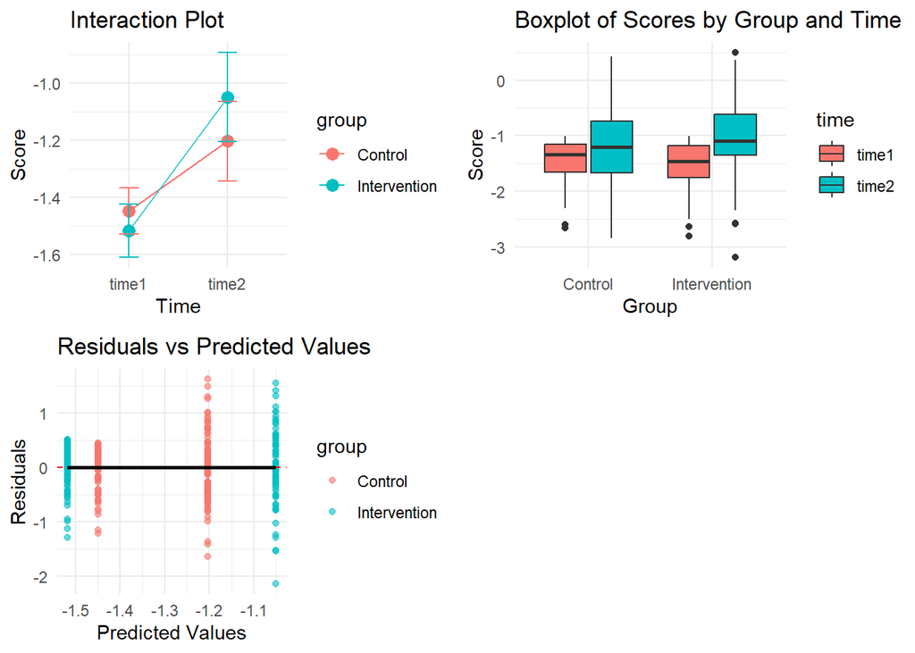

```r
# Visualization
p1 <- ggplot(data_long, aes(x = time, y = score, color = group, group = group)) +
  stat_summary(fun = mean, geom = "point", size = 3) +
  stat_summary(fun = mean, geom = "line") +
  stat_summary(fun.data = mean_cl_normal, geom = "errorbar", width = 0.2) +
  labs(title = "Interaction Plot", x = "Time", y = "Score") +
  theme_minimal()

p2 <- ggplot(data_long, aes(x = group, y = score, fill = time)) +
  geom_boxplot() +
  labs(title = "Boxplot of Scores by Group and Time", x = "Group", y = "Score") +
  theme_minimal()

# Residual plot
model <- lm(score ~ time * group, data = data_long)
data_long$predicted <- predict(model)
data_long$residuals <- residuals(model)

p3 <- ggplot(data_long, aes(x = predicted, y = residuals, color = group)) +
  geom_point(alpha = 0.6) +
  geom_hline(yintercept = 0, linetype = "dashed", color = "red") +
  geom_smooth(method = "loess", se = FALSE, color = "black") +
  labs(title = "Residuals vs Predicted Values",
       x = "Predicted Values",
       y = "Residuals") +
  theme_minimal()

# Arrange plots
grid.arrange(p1, p2, p3, ncol = 2, nrow = 2)
```

```r
# Print model summary
summary(model)
```

```
##
## Call:
## lm(formula = score ~ time * group, data = data_long)
##
## Residuals:
##      Min       1Q   Median       3Q      Max
## -2.14262 -0.34102  0.05091  0.34473  1.62359
##
## Coefficients:
##                             Estimate Std. Error t value Pr(>|t|)
## (Intercept)                 -1.44860    0.05892 -24.587  < 2e-16 ***
## timetime2                    0.24455    0.08332   2.935  0.00357 **
## groupIntervention           -0.06945    0.08625  -0.805  0.42127
## timetime2:groupIntervention  0.22342    0.12197   1.832  0.06789 .
## ---
## Signif. codes:  0 '***' 0.001 '**' 0.01 '*' 0.05 '.' 0.1 ' ' 1
##
## Residual standard error: 0.5527 on 326 degrees of freedom
## Multiple R-squared:  0.1012, Adjusted R-squared:  0.09291
## F-statistic: 12.23 on 3 and 326 DF,  p-value: 1.325e-07
```

```r
# Test for heteroscedasticity
levene_test <- leveneTest(score ~ group * time, data = data_long)
print(levene_test)
```

```
## Levene's Test for Homogeneity of Variance (center = median)
##        Df F value    Pr(>F)
## group   3  11.545 3.275e-07 ***
##       326
## ---
## Signif. codes:  0 '***' 0.001 '**' 0.01 '*' 0.05 '.' 0.1 ' ' 1
```

With only two time points, we cannot fit a random slope for time (need at least 3). Also, obtaining effect sizes from a random effects model is non-trivial.

```r
# Fit random-effects model
random_effects_model <- lmer(score ~ time * group + (1|id), data = data_long)

# Print model summary
summary(random_effects_model)
```

```
## Linear mixed model fit by REML ['lmerMod']
## Formula: score ~ time * group + (1 | id)
##    Data: data_long
##
## REML criterion at convergence: 523.3
##
## Scaled residuals:
##      Min       1Q   Median       3Q      Max
## -2.66399 -0.57487 -0.02631  0.54601  2.58835
##
## Random effects:
##  Groups   Name        Variance Std.Dev.
##  id       (Intercept) 0.1306   0.3614
##  Residual             0.1748   0.4181
## Number of obs: 330, groups:  id, 165
##
## Fixed effects:
##                             Estimate Std. Error t value
## (Intercept)                 -1.44860    0.05892 -24.587
## timetime2                    0.24455    0.06304   3.879
## groupIntervention           -0.06945    0.08625  -0.805
## timetime2:groupIntervention  0.22342    0.09228   2.421
##
## Correlation of Fixed Effects:
##             (Intr) timtm2 grpInt
## timetime2   -0.535
## grpIntrvntn -0.683  0.365
## tmtm2:grpIn  0.365 -0.683 -0.535
```

Change score effect size is still inflated (we expect it to be ~0.2).

```r
# Calculate change scores
data$change <- data$time2 - data$time1

# Fit linear model on change scores
change_model <- lm(change ~ group, data = data)

# Print model summary
print(summary(change_model))
```

```
##
## Call:
## lm(formula = change ~ group, data = data)
##
## Residuals:
##      Min       1Q   Median       3Q      Max
## -1.36244 -0.39714 -0.01223  0.40821  1.44006
##
## Coefficients:
##                   Estimate Std. Error t value Pr(>|t|)
## (Intercept)        0.24455    0.06304   3.879 0.000152 ***
## groupIntervention  0.22342    0.09228   2.421 0.016565 *
## ---
## Signif. codes:  0 '***' 0.001 '**' 0.01 '*' 0.05 '.' 0.1 ' ' 1
##
## Residual standard error: 0.5913 on 163 degrees of freedom
## Multiple R-squared:  0.03472,    Adjusted R-squared:  0.02879
## F-statistic: 5.862 on 1 and 163 DF,  p-value: 0.01657
```

```r
# Calculate effect size
cohens_d <- coef(change_model)["groupIntervention"] / sd(data$change)
print(paste("Cohen's d:", cohens_d))
```

```
## [1] "Cohen's d: 0.372347219674974"
```

## Using a hybrid Mee-Chua and ANCOVA approach:

I recommend an analysis that extends Mee & Chua’s (1991) regression-to-mean correction to compare groups while allowing for differential regression-to-mean effects between groups.

1. Using Mee-Chua’s framework to test if each group’s improvement exceeds regression to mean
2. Employing ANCOVA-like modeling to estimate group differences and RTM interactions
3. Calculating group effects while properly accounting for differential RTM patterns
4. Where needed, using HC3 robust standard errors to handle potential heteroscedasticity

Key advantages are that the approach tests each group’s improvement against regression to mean (Mee-Chua tests), compares groups while allowing for different RTM patterns (Group effect test), and maintains interpretability even with heterogeneous RTM effects.

```
Results show traditional analyses inflated effect sizes:
- Intervention d = 0.8 (approx) (vs true 0.2)
- Control d = 0.4 (approx) (vs true 0)
- Change score analysis d = 0.38 (approx) (vs true 0.2)

while this approach recovers the true effect size (0.221 ≈ 0.2)
```

```r
# Gab's hybrid Mee-Chua analysis function with optional HC3
mee_chua_hybrid <- function(test1, test2, group, population_mean,
                          include_interaction = TRUE,
                          use_hc3 = FALSE,
                          group_labels = c("control", "intervention"),
                          alpha = 0.05) {
  # validating inputs
  if (length(test1) != length(test2) || length(test1) != length(group)) {
    stop("test1, test2, and group must have the same length")
  }

  if (!is.numeric(population_mean)) {
    stop("population_mean must be numeric")
  }

  # load sandwich package if HC3 is requested
  if (use_hc3 && !requireNamespace("sandwich", quietly = TRUE)) {
    stop("Package 'sandwich' is needed for HC3 standard errors. Please install it.")
  }

  # create the data frame for analysis
  data <- data.frame(
    Y1 = test1,
    Y2 = test2,
    group = factor(group, levels = group_labels)
  )

  # center Y1 around population mean
  data$X <- data$Y1 - population_mean

  # create group dummy (0=control, 1=intervention)
  data$G <- as.numeric(data$group) - 1

  # create interaction term for regression-to-the-mean differences
  data$GX <- data$G * data$X

  # fit models
  if(include_interaction) {
    model <- lm(Y2 ~ G + X + GX, data = data)
  } else {
    model <- lm(Y2 ~ G + X, data = data)
  }

  # calculate the appropriate variance-covariance matrix
  if(use_hc3) {
    vcov_matrix <- sandwich::vcovHC(model, type = "HC3")
  } else {
    vcov_matrix <- vcov(model)
  }

  # extract coefficients and MSE
  coef_summary <- summary(model)$coefficients
  mse <- summary(model)$sigma^2

  # calculate components for Mee-Chua t-statistics
  n_control <- sum(data$G == 0)
  n_intervention <- sum(data$G == 1)
  X_bar_control <- mean(data$X[data$G == 0])
  X_bar_intervention <- mean(data$X[data$G == 1])
  SS_X_control <- sum((data$X[data$G == 0] - X_bar_control)^2)
  SS_X_intervention <- sum((data$X[data$G == 1] - X_bar_intervention)^2)

  # writing a function to calculate Mee-Chua t-statistic for control group
  mc_t_stat_control <- function(beta, mu) {
    (beta - mu) / sqrt(mse * (1/n_control + X_bar_control^2/SS_X_control))
  }

  # writing a function to calculate Mee-Chua t-statistic for intervention group
  mc_t_stat_intervention <- function(beta, mu) {
    (beta - mu) / sqrt(mse * (1/n_intervention + X_bar_intervention^2/SS_X_intervention))
  }

  # calculate t-statistics and p-values for control group
  beta0_control <- coef_summary["(Intercept)", "Estimate"]
  t_control <- mc_t_stat_control(beta0_control, population_mean)
  p_control <- pt(t_control, df = model$df.residual, lower.tail = FALSE)

  # calculate effects for intervention group
  beta_group <- coef_summary["G", "Estimate"]
  beta0_intervention <- beta0_control + beta_group
  beta_p_control <- coef_summary["X", "Estimate"]

  # calculate t-statistics and p-values for intervention group
  t_intervention <- mc_t_stat_intervention(beta0_intervention, population_mean)
  p_intervention <- pt(t_intervention, df = model$df.residual, lower.tail = FALSE)

  if(include_interaction) {
    beta_interaction <- coef_summary["GX", "Estimate"]
    beta_p_intervention <- beta_p_control + beta_interaction

    # grab the HC3 (or standard) t-stat and p-value for interaction
    se_interaction <- sqrt(vcov_matrix["GX", "GX"])
    t_interaction <- beta_interaction / se_interaction
    p_interaction <- 2 * pt(abs(t_interaction), df = model$df.residual,
                           lower.tail = FALSE)
  } else {
    beta_interaction <- 0
    beta_p_intervention <- beta_p_control
    t_interaction <- NA
    p_interaction <- NA
  }

  # calculate group difference at mean of X with appropriate SE, accounting for regression-to-the-mean
  group_diff_at_mean <- beta_group + beta_interaction * X_bar_control

  # calculate the standard error for group difference using selected vcov matrix
  se_group_diff <- sqrt(
    vcov_matrix["G", "G"] +
    X_bar_control^2 * vcov_matrix["GX", "GX"] +
    2 * X_bar_control * vcov_matrix["G", "GX"]
  )

  # t-statistic and p-value for group difference
  t_group_diff <- group_diff_at_mean / se_group_diff
  p_group_diff <- 2 * pt(abs(t_group_diff), df = model$df.residual,
                         lower.tail = FALSE)

  # calculate 95% confidence intervals
  # we use the original Mee-Chua CI for control intercept
  ci_control <- beta0_control +
    qt(c(alpha/2, 1-alpha/2), model$df.residual) *
    sqrt(mse * (1/n_control + X_bar_control^2/SS_X_control))
  names(ci_control) <- c("lower", "upper")

  # also use Mee-Chua CI for intervention intercept
  ci_intervention <- beta0_intervention +
    qt(c(alpha/2, 1-alpha/2), model$df.residual) *
    sqrt(mse * (1/n_intervention + X_bar_intervention^2/SS_X_intervention))
  names(ci_intervention) <- c("lower", "upper")

  # we calculate a hc3 CI for group difference by using the hc3 SE
  ci_group_diff <- group_diff_at_mean +
    qt(c(alpha/2, 1-alpha/2), model$df.residual) * se_group_diff
  names(ci_group_diff) <- c("lower", "upper")

  # create results list
  results <- list(
    control = list(
      beta0 = beta0_control,
      beta_p = beta_p_control,
      t_stat = t_control,
      p_value = p_control,
      ci = ci_control
    ),
    intervention = list(
      beta0 = beta0_intervention,
      beta_p = beta_p_intervention,
      t_stat = t_intervention,
      p_value = p_intervention,
      ci = ci_intervention
    ),
    group_effect = list(
      estimate = group_diff_at_mean,
      se = se_group_diff,
      t_stat = t_group_diff,
      p_value = p_group_diff,
      ci = ci_group_diff
    ),
    interaction = if(include_interaction) list(
      estimate = beta_interaction,
      se = se_interaction,
      t_stat = t_interaction,
      p_value = p_interaction
    ) else NULL,
    model = model,
    population_mean = population_mean,
    alpha = alpha,
    group_labels = group_labels,
    include_interaction = include_interaction,
    use_hc3 = use_hc3
  )

  class(results) <- "mee_chua_hybrid"
  return(results)
}

# print method to show tests for both groups
print.mee_chua_hybrid <- function(x, ...) {
  cat("\nMee-Chua corrections", if(x$use_hc3) "with HC3 robust SEs\n" else "\n")
  cat("\nPopulation mean:", x$population_mean, "\n")

  # control group results
  cat("\nControl Group (", x$group_labels[1], "):\n", sep="")
  cat("β₀ =", round(x$control$beta0, 3), "\n")
  cat("βp =", round(x$control$beta_p, 3), "\n")
  cat("H₀: β₀ = μ vs H₁: β₀ > μ\n")
  cat("t =", round(x$control$t_stat, 3),
      "p =", format.pval(x$control$p_value), "\n")
  cat(paste0((1-x$alpha)*100, "% CI for β₀: [",
             round(x$control$ci["lower"], 3), ", ",
             round(x$control$ci["upper"], 3), "]\n"))

  # intervention group results
  cat("\nIntervention Group (", x$group_labels[2], "):\n", sep="")
  cat("β₀ =", round(x$intervention$beta0, 3), "\n")
  cat("βp =", round(x$intervention$beta_p, 3), "\n")
  cat("H₀: β₀ = μ vs H₁: β₀ > μ\n")
  cat("t =", round(x$intervention$t_stat, 3),
      "p =", format.pval(x$intervention$p_value), "\n")
  cat(paste0((1-x$alpha)*100, "% CI for β₀: [",
             round(x$intervention$ci["lower"], 3), ", ",
             round(x$intervention$ci["upper"], 3), "]\n"))

  # group effect (difference at mean of X)
  cat("\nGroup Effect (Intervention - Control) at mean of X:\n")
  cat("Estimate =", round(x$group_effect$estimate, 3), "\n")
  cat("SE =", round(x$group_effect$se, 3), "\n")
  cat("t =", round(x$group_effect$t_stat, 3),
      "p =", format.pval(x$group_effect$p_value), "\n")
  cat(paste0((1-x$alpha)*100, "% CI: [",
             round(x$group_effect$ci["lower"], 3), ", ",
             round(x$group_effect$ci["upper"], 3), "]\n"))

  # interaction effect if included
  if(x$include_interaction) {
    cat("\nDifference in regression-to-the-mean (βint):\n")
    cat("Estimate =", round(x$interaction$estimate, 3), "\n")
    cat("SE =", round(x$interaction$se, 3), "\n")
    cat("t =", round(x$interaction$t_stat, 3),
        "p =", format.pval(x$interaction$p_value), "\n")
  }
  cat("\n")
}
```

Using an ANCOVA (including Mee and Chua’s recommended tests for the group intercepts), we were able to recover the true effect size (≈ 0.2), while the earlier analyses showed inflated effects:

```r
# First prepare the data in the format needed for mee_chua_hybrid
# We need test1, test2, group, and population_mean

# Let's use it with both standard and HC3 versions
results_standard <- mee_chua_hybrid(
    test1 = data$time1,
    test2 = data$time2,
    group = data$group,
    population_mean = 0,  # Original population mean was 0
    include_interaction = TRUE,
    use_hc3 = FALSE,
    group_labels = c("Control", "Intervention")
)

results_hc3 <- mee_chua_hybrid(
    test1 = data$time1,
    test2 = data$time2,
    group = data$group,
    population_mean = 0,
    include_interaction = TRUE,
    use_hc3 = TRUE,
    group_labels = c("Control", "Intervention")
)

# Print both results
cat("\nStandard Analysis:\n")
```

```
##
## Standard Analysis:
```

```r
print(results_standard)
```

```
##
## Mee-Chua corrections
##
## Population mean: 0
##
## Control Group (Control):
## β₀ = -0.211
## βp = 0.685
## H₀: β₀ = μ vs H₁: β₀ > μ
## t = -0.864 p = 0.80566
## 95% CI for β₀: [-0.694, 0.271]
##
## Intervention Group (Intervention):
## β₀ = 0.411
## βp = 0.963
## H₀: β₀ = μ vs H₁: β₀ > μ
## t = 1.595 p = 0.056286
## 95% CI for β₀: [-0.098, 0.921]
##
## Group Effect (Intervention - Control) at mean of X:
## Estimate = 0.221
## SE = 0.092
## t = 2.388 p = 0.018105
## 95% CI: [0.038, 0.403]
##
## Difference in regression-to-the-mean (βint):
## Estimate = 0.277
## SE = 0.231
## t = 1.199 p = 0.23217
```

```r
cat("\nHC3 Robust Analysis:\n")
```

```
##
## HC3 Robust Analysis:
```

```r
print(results_hc3)
```

```
##
## Mee-Chua corrections with HC3 robust SEs
##
## Population mean: 0
##
## Control Group (Control):
## β₀ = -0.211
## βp = 0.685
## H₀: β₀ = μ vs H₁: β₀ > μ
## t = -0.864 p = 0.80566
## 95% CI for β₀: [-0.694, 0.271]
##
## Intervention Group (Intervention):
## β₀ = 0.411
## βp = 0.963
## H₀: β₀ = μ vs H₁: β₀ > μ
## t = 1.595 p = 0.056286
## 95% CI for β₀: [-0.098, 0.921]
##
## Group Effect (Intervention - Control) at mean of X:
## Estimate = 0.221
## SE = 0.093
## t = 2.381 p = 0.018435
## 95% CI: [0.038, 0.404]
##
## Difference in regression-to-the-mean (βint):
## Estimate = 0.277
## SE = 0.232
## t = 1.196 p = 0.2334
```